# Masking the Conclusion

Anthony A

10/4/2022

# Abstract

We do some data tidying and light feature engineering but create strikingly different visualizations. The conclusions that would be inferred between the two are drastic. However, after doing a statistical analysis, the math reveals that one is much more desirable.

# Datasets

```r
path = "./data/"
file = "airport_trips.csv"
url = "https://raw.githubusercontent.com/Anthogonyst/607-Acquisition/master/data/airport_trips.csv"

### Prefer local files, otherwise read from web
rawData = paste0(path, file) %>%
  ifelse(file.exists(.), ., url) %>%
    read.csv(.)
```

# Data Wrangling

My initial input file was formatted to look pretty on a report but not so good for a database. After some tidying, I convert the data into a long format first.

```r
### Fills some empty spaces and then converts via dictionary to a long format
flightData = rawData %>%
  magrittr::set_colnames(., gsub("\\.", " ", colnames(.))) %>%
    { .[. == ""] = NA ; . } %>%
      zoo::na.locf(.) %>%
        .[! duplicated(.), ] %>%
          reshape2::melt(., id = c("X", "X 1")) %>%
            magrittr::set_colnames(., c("Airline", "Status", "Airport", "Flights"))
```

# Initial Thoughts

When I compiled my exploratory analysis into a visualization, an overly simply idea occurred to me. I thought that I would probably be late on 1/10 flights regardless of what airline I chose. Visually, both airlines seem to have equally proportionate data to their number of flights and their arrival delays. (Note the values of counted flights is actually the square root.)

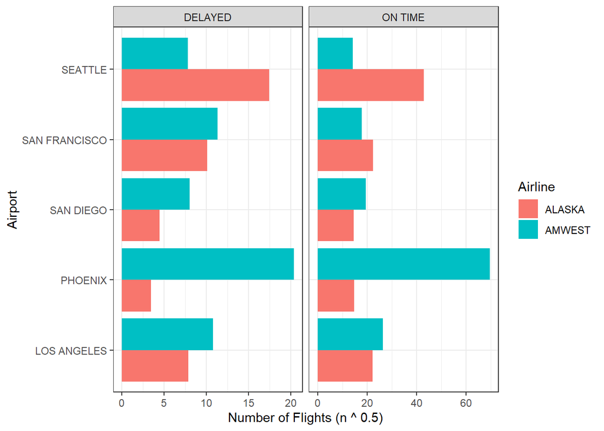

```r
ggplot2::ggplot(flightData) +
  ggplot2::aes(
    y = Airport,
    fill = Airline,
    group = Airline,
    weight = sqrt(Flights)
  ) +
  ggplot2::geom_bar(position = "dodge") +
  ggplot2::labs(x = "Number of Flights (n ^ 0.5)") +
  ggplot2::scale_fill_hue(direction = 1) +
  ggplot2::theme_bw() +
  ggplot2::facet_wrap(ggplot2::vars(Status), scales = "free_x")
```

# Contradictory Evidence

```r
### Makes a 3d dataset to compare 3 features; probably not the best approach
percentDelays = reshape2::acast(flightData, Airline ~ Airport ~ Status, value.var = "Flights") %>%
  { .[,,1] / (.[,,1] + .[,,2]) } %>%
    print(.) %>%
      reshape2::melt(.) %>%
        magrittr::set_colnames(., c("Airline", "Airport", "% Delayed"))
```

```
##        LOS ANGELES    PHOENIX SAN DIEGO SAN FRANCISCO   SEATTLE
## ALASKA   0.1109123 0.05150215 0.0862069     0.1685950 0.1421249
## AMWEST   0.1442663 0.07897241 0.1450893     0.2873051 0.2328244
```

# Finding “The Lie” in the Data

Going back, I want to understand why my graph looks so different from the calculations. The 1/10 number wasn’t too far off but one airport is so obviously superior that you have to wonder. Apparently, the combination of feature engineering compresses the data and the facet draw separates it just enough to hide the trend! It is now clear that Alaska Airlines is superior in terms of quality, despite that AM West is much more prominent in Phoenix.

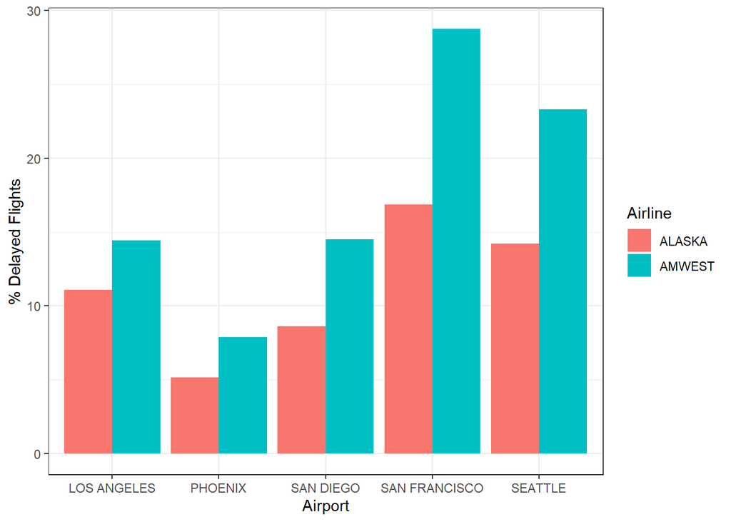

```r
### Does a similar operation to get all of the flights combined (optional but nice for completeness)
completeData = reshape2::acast(flightData, Airline ~ Airport ~ Status, value.var = "Flights") %>%
  { .[,,1] + .[,,2] } %>%
    reshape2::melt(.) %>%
      magrittr::set_colnames(., c("Airline", "Airport", "Total Flights")) %>%
        dplyr::left_join(percentDelays, ., by = c("Airline", "Airport")) %>%
          dplyr::left_join(flightData, ., by = c("Airline", "Airport"))

### Our join produces two rows of data respective to the two statuses, so we filter for either one
### If we don't filter, the weight will count both rows and double its intended value
### From a design POV, this can be completely avoided by not doing the other join but makes other analyses easier
completeData %>%
  dplyr::filter(Status == "ON TIME") %>%
    ggplot2::ggplot(.) +
    ggplot2::aes(
      x = Airport,
      fill = Airline,
      group = Airline,
      weight = `% Delayed` * 100
    ) +
    ggplot2::geom_bar(position = "dodge") +
    ggplot2::scale_fill_hue(direction = 1) +
    ggplot2::labs(y = "% Delayed Flights") +
    ggplot2::theme_bw()
```